# IntOMICS tutorial

## Summary

IntOMICS is an efficient integrative framework based on Bayesian networks. IntOMICS systematically analyses gene expression, copy number variation, DNA methylation, and biological prior knowledge to infer regulatory networks. IntOMICS complements the missing biological prior knowledge by so-called empirical biological knowledge, estimated from the available experimental data. An automatically tuned MCMC algorithm (Yang and Rosenthal, 2017) estimates model parameters and the empirical biological knowledge. Conventional MCMC algorithm with additional Markov blanket resampling step (Su and Borsuk, 2016) infers resulting regulatory network structure consisting of three types of nodes: GE nodes refer to gene expression levels, CNV nodes refer to associated copy number variations, and METH nodes refer to associated DNA methylation probe(s). The resulting regulatory network structure contains the edge weights $w_i$ representing the empirical frequency of given edge over samples of network structures from two independent MCMC simulations. For further details, see Pacinkova & Popovici, 2022.

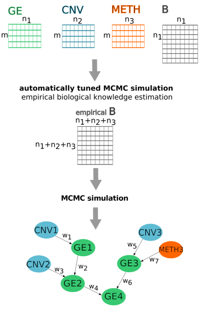

IntOMICS framework

$$\\[0.1in]$$

This tutorial will show you how to use the IntOMICS package with a toy example. The example dataset is from the TCGA data portal (https://portal.gdc.cancer.gov/): 30 colon cancer samples (COAD) with microsatellite instability (MSI). We choose the set of 7 genes from the KEGG Colorectal cancer pathway (https://www.genome.jp/pathway/hsa05210).

```r
library(knitr)
library(IntOMICS)
library(bestNormalize)
library(foreach)
library(bnlearn)
library(RColorBrewer)
library(png)
library(matrixStats)
suppressMessages(library(igraph))
suppressMessages(library(ggraph))
suppressMessages(library(bnstruct))
```

## Part 1: Input data

IntOMICS framework takes as input:

1. gene expression matrix $GE$ ($m$ x $n_1$) with microarray intensities or RNA-seq count data transformed into a continuous domain ($m$ samples and $n_1$ features)
2. associated copy number variation matrix $CNV$ ($m$ x $n_2$) with continuous segment mean values derived for each gene ($n_2 \leq n_1$),
3. associated DNA methylation matrix of beta-values $METH$ ($m$ x $n_3$),
4. data.frame including all known interactions between molecular features (information from public available databases such as KEGG (Ogata et al., 1999) or REACTOME (Wu & Haw, 2017)). However, any other source of prior knowledge can be used.

All data matrices are sampled from the same individuals.

```r
omics$ge[1:5,1:5]
```

```
#>              ENTREZID:673 ENTREZID:3845 ENTREZID:4609 ENTREZID:5604
#> TCGA-A6-5661     5.626990      5.718158      5.418139      4.569792
#> TCGA-AD-5900     3.268475      4.898989      7.867263      5.182608
#> TCGA-CM-4743     3.400621      5.468644      6.761254      5.418349
#> TCGA-G4-6586     3.480572      5.034181      6.888025      5.553441
#> TCGA-F4-6570     3.814445      4.634686      7.051842      4.906874
#>              ENTREZID:5594
#> TCGA-A6-5661      7.248533
#> TCGA-AD-5900      6.054980
#> TCGA-CM-4743      6.042386
#> TCGA-G4-6586      6.143032
#> TCGA-F4-6570      6.350766
```

These values correspond to normalised RNA-seq data. However, the user is not limited to this platform. Another assay, such as microarray data, can be used. The column names of omics$ge matrix must be entrez ID in the format ENTREZID:XXXX.

```r
omics$cnv[1:5,1:5]
```

```
#>              entrezid:673 entrezid:3845 entrezid:4609 entrezid:5604
#> TCGA-A6-5661        0.008         0.004        -0.004         0.003
#> TCGA-AD-5900       -0.001         0.507         0.749         0.000
#> TCGA-CM-4743        0.004        -0.004        -0.003        -0.003
#> TCGA-G4-6586       -0.023         0.004        -0.007         0.010
#> TCGA-F4-6570       -0.002         0.005         0.223         0.003
#>              entrezid:5594
#> TCGA-A6-5661        -0.004
#> TCGA-AD-5900        -0.009
#> TCGA-CM-4743        -0.021
#> TCGA-G4-6586        -0.003
#> TCGA-F4-6570         0.009
```

These copy number values represent segment mean values equal to $log_2(\frac{copy-number}{2})$. The column names of omics$cnv matrix must be entrez ID in the format entrezid:XXXX. In the omics$cnv matrix, define only columns with available CNV data.

```r
omics$meth[1:5,1:5]
```

```
#>              cg06108510 cg07101782 cg17641046 cg25202636 cg03497419
#> TCGA-A6-5661  0.6042037  0.5550869  0.6473482  0.5234418  0.5671736
#> TCGA-AD-5900  0.5173069  0.4365084  0.6672522  0.5742973  0.4907275
#> TCGA-CM-4743  0.4490056  0.3934676  0.5471020  0.4236996  0.4318266
#> TCGA-G4-6586  0.6372390  0.6085915  0.7351724  0.6520927  0.6764021
#> TCGA-F4-6570  0.6641252  0.6076128  0.6589021  0.5845556  0.6457823
```

These values represent DNA methylation beta values. The column names of the omics$meth matrix are probe IDs.

IntOMICS is designed to infer regulatory networks even if the copy number variation or DNA methylation data (or both) are not available.

If methylation data are available, we have to provide an annotation:

```r
str(annot)
```

```
#> List of 7
#>  $ ENTREZID:4292: chr [1:6] "cg06108510" "cg07101782" "cg17641046" "cg25202636" ...
#>  $ ENTREZID:5594: chr [1:19] "cg11335969" "cg23681311" "cg00014104" "cg00578437" ...
#>  $ ENTREZID:5595: chr [1:10] "cg02286008" "cg05902503" "cg02521996" "cg05445914" ...
#>  $ ENTREZID:3845: chr [1:29] "cg12990174" "cg20836156" "cg00584022" "cg02850821" ...
#>  $ ENTREZID:4609: chr [1:40] "cg00163372" "cg08526705" "cg11688275" "cg15801573" ...
#>  $ ENTREZID:673 : chr [1:19] "cg14094063" "cg20200035" "cg26956263" "cg01510153" ...
#>  $ ENTREZID:5604: chr [1:21] "cg00098814" "cg05866062" "cg08161449" "cg11559852" ...
```

annot is a named list. Each component of the list is a character vector and corresponds to probe IDs associated with a given gene. Names of the annot must be again in the format ENTREZID:XXXX.

To generate comprehensive figures with gene IDs, we need to provide a gene annotation table:

```r
gene_annot
```

```
#>         entrezID gene_symbol
#> 18  ENTREZID:673        BRAF
#> 15 ENTREZID:3845        KRAS
#> 24 ENTREZID:4609         MYC
#> 26 ENTREZID:5604      MAP2K1
#> 27 ENTREZID:5594       MAPK1
#> 28 ENTREZID:5595       MAPK3
#> 41 ENTREZID:4292        MLH1
```

gene_annot is Gene ID conversion table with “entrezID” and “gene_symbol” column names. Gene symbols are used for the final regulatory network visualisation.

And finally, the prior knowledge from any source chosen by the user:

```r
PK
```

```
#>                                                 src_entrez   dest_entrez
#> Long-term depression.144                      ENTREZID:673 ENTREZID:5604
#> EGFR tyrosine kinase inhibitor resistance.18 ENTREZID:3845  ENTREZID:673
#> EGFR tyrosine kinase inhibitor resistance.22 ENTREZID:5604 ENTREZID:5594
#> EGFR tyrosine kinase inhibitor resistance.23 ENTREZID:5604 ENTREZID:5595
#> EGFR tyrosine kinase inhibitor resistance.26 ENTREZID:5594 ENTREZID:4609
#> EGFR tyrosine kinase inhibitor resistance.33 ENTREZID:5595 ENTREZID:4609
#>                                              edge_type
#> Long-term depression.144                       present
#> EGFR tyrosine kinase inhibitor resistance.18   present
#> EGFR tyrosine kinase inhibitor resistance.22   present
#> EGFR tyrosine kinase inhibitor resistance.23   present
#> EGFR tyrosine kinase inhibitor resistance.26   present
#> EGFR tyrosine kinase inhibitor resistance.33   present
```

PK is the data.frame with biological prior knowledge. Column names are “src_entrez” (the parent node), “dest_entrez” (the child node) and “edge_type” (the prior knowledge about the direct interaction between parent and child node; the allowed values are “present” or “missing”).

## Part 2: Data preprocessing

The first step is to define the biological prior matrix and estimate the upper bound of the partition function needed to define the prior distribution of network structures. We also need to define all possible parent set configurations for each node. For each parent set configuration, we compute the energy (needed to define the prior distribution of network structures) and the BGe score (needed to determine the posterior probability of network structures). These functionalities are available through the function.  
We can use linear regression to filter irrelevant DNA methylation probes. We set the parameter lm_METH = TRUE (default lm_METH = TRUE). We can also specify the threshold for the R^2 to choose DNA methylation probes with significant coefficient using the r_squared_thres (default = 0.3).

```r
OMICS_module_res <- OMICS_module(omics = omics, PK = PK, layers_def = layers_def, annot = annot, r_squared_thres = 0.3, lm_METH = TRUE)
```

These DNA methylation probes passed the filter:

```r
OMICS_module_res$annot
```

[output not shown]

## Part 3: MCMC simulation

Now, we can use the automatically tuned MCMC algorithm (Yang and Rosenthal, 2017) to estimate model parameters and empirical biological knowledge and the conventional MCMC algorithm with additional Markov blanket resampling step (Su and Borsuk, 2016) to infer regulatory network structure consisting of three types of nodes: GE, CNV and METH nodes. This step can be time-consuming (you can skip it and use the pre-computed result -> R object BN_module_res).

```r
BN_module_res <- BN_module(burn_in = 100000,
                           thin = 500,
                           seed1 = 1001,
                           seed2 = 2002,
                           OMICS_module_res = OMICS_module_res,
                           minseglen = 50000)
```

## Part 4: MCMC diagnostics

Now we have to create a directory to store trace plots. Once it is created, we can run the trace_plots function, which generates:

1. beta_values.svg: trace plot of beta values (we want to explore the sample space many times and avoid flat bits - the chain stays in the same state for too long)
2. post_prob_edges.svg: consistency of edges posterior probabilities in two independent MCMC simulations (scatter plot of the edge weights confidence using two independent MCMC runs; the convergence is determined by the spread of the points around the y=x line)
3. convergence_RMS.svg: the c_{rms} strength for the convergence evaluation (summarizes the spread of the points around the line y=x in post_prob_edges.svg, for details see (Agostinho et al., 2015 and Pacinkova & Popovici, 2022)).

The parameter edge_freq_thres determines the quantile of all edge weights used to filter only reliable edges. The parameter gene_ID determines the IDs used in the final network. There are two options: ‘gene_symbol’ (default) or ‘entrezID’.

```r
res_weighted <- trace_plots(mcmc_res = BN_module_res, figures_dir = "figures/MSI/", burn_in = 100000, thin = 500, gene_annot = gene_annot, PK = PK, OMICS_module_res = OMICS_module_res, gene_ID = "gene_symbol", edge_freq_thres = 0.75)
```

## Part 5: IntOMICS resulting network structure

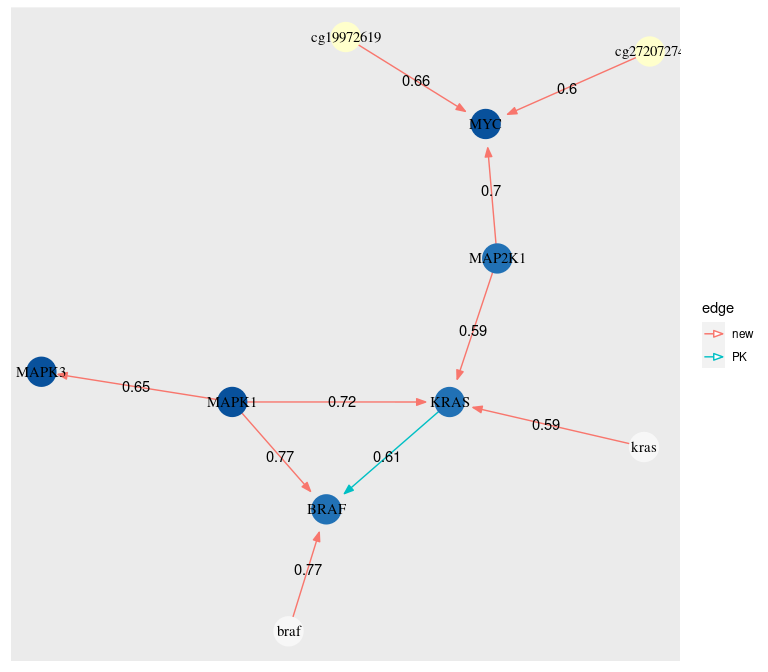

```r
ggraph(res_weighted$net_weighted, layout = 'dh') +
  geom_edge_link(aes(end_cap = circle(node2.degree + 7, "pt"), edge_color = edge, label = weight),
                 arrow = arrow(angle = 20, length = unit(0.1, "inches"),
                              ends = "last", type = "closed"))+
  geom_node_point(aes(color = factor(color)), size = 10) +
  scale_colour_manual(values = res_weighted$node_palette, guide = "none")+
  geom_node_text(aes(label = label),family="serif")
```

Node colours legend:

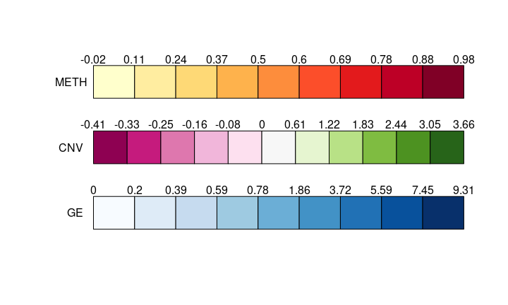

```r
legend_custom(net = res_weighted)
```

Node colour scales are given by GE/CNV/METH values of all features from the corresponding input data matrix.

If you find a bug or have a comment let us know, please, via an e-mail: ana.pacinkova@gmail.com

## References

Yang, J. & Rosenthal, J. S. (2017). Automatically tuned general-purpose MCMC via new adaptive diagnostics. Computational Statistics, 32, 315 – 348.  
Su, C. & Borsuk, M. E. (2016). Improving Structure MCMC for Bayesian Networks through Markov Blanket Resampling. Journal of Machine Learning Research, 17, 1 – 20.  
Pacinkova, A. & Popovici, V. (2022). Using Empirical Biological Knowledge to Infer Regulatory Networks From Multi-omics Data. doi: 10.21203/rs.3.rs-1291540/v1  
Ogata, H., et al. (1999). KEGG: Kyoto Encyclopedia of Genes and Genomes. Nucleic Acids Res 27, 29–34.  
Wu, G. & Haw, R. (2017). Functional Interaction Network Construction and Analysis for Disease Discovery. Methods Mol Biol. 1558, 235–253.  
Agostinho, N. B. et al. (2015). Inference of regulatory networks with a convergence improved MCMC sampler. BMC Bioinformatics, 16.